# Case Study: How does a bike share navigate speedy success?

Clayton

2022-10-13

## Background

In 2016, Cyclistic launched a successful bike-share offering. Since then, the program has grown to a fleet of 5,824 bicycles that are geotracked and locked into a network of 692 stations across Chicago. The bikes can be unlocked from one station and returned to any other station in the system anytime.

Until now, Cyclistic’ s marketing strategy relied on building general awareness and appealing to broad consumer segments. One approach that helped make these things possible was the flexibility of its pricing plans: single-ride passes, full-day passes, and annual memberships. Customers who purchase single-ride or full-day passes are referred to as casual riders. Customers who purchase annual memberships are Cyclistic members.

Cyclistic’ s finance analysts have concluded that annual members are much more profitable than casual riders. Although the pricing flexibility helps Cyclistic attract more customers, Moreno(director of marketing) believes that maximizing the number of annual members will be key to future growth. Rather than creating a marketing campaign that targets all-new customers, Moreno believes there is a very good chance to convert casual riders into members. She notes that casual riders are already aware of the Cyclistic program and have chosen Cyclistic for their mobility needs

## Goals

Design marketing strategies aimed at converting casual riders into annual members. To do that, however, the marketing analyst team needs to better understand how annual members and casual riders differ, why casual riders would buy a membership, and how digital media could affect their marketing tactics. Moreno and her team are interested in analyzing the Cyclistic historical bike trip data to identify trends

# Ask

Three questions will guide the future marketing program: 1. How do annual members and casual riders use Cyclistic bikes differently? 2. Why would casual riders buy Cyclistic annual memberships? 3. How can Cyclistic use digital media to influence casual riders to become members?

### Objectives

This Analysis will focus on the first question. (How do annual members and casual riders use Cyclistic bikes differently?)

# Prepare

### Load Libraries

Load the data and packages. Also setup working directory . All packages already installed.

```r
library(dplyr)# we wll use some o its functions for manipulation(helps wrangle data)
library(tidyverse)  #helps wrangle data
library(lubridate)  #helps wrangle date attributes
```

```r
library(ggplot2)  #helps visualize data
options(dplyr.summarise.inform = FALSE)# this suppresses the summarise group warnings
#getwd() #displays your working directory
setwd("/Users/clayt/OneDrive/Documents/R Programming Projects/capstone_project")#sets  working directory
options(readr.show_types = FALSE)
```

## STEP 1: COLLECT DATA

This stage we downloaded data and imported it into R.

```r
oct_2021 <- read_csv("202110-divvy-tripdata.csv")
nov_2021 <- read_csv("202111-divvy-tripdata.csv")
dec_2021 <- read_csv("202112-divvy-tripdata.csv")
jan_2022 <- read_csv("202201-divvy-tripdata.csv")
feb_2022 <- read_csv("202202-divvy-tripdata.csv")
mar_2022 <- read_csv("202203-divvy-tripdata.csv")
apr_2022 <- read_csv("202204-divvy-tripdata.csv")
may_2022 <- read_csv("202205-divvy-tripdata.csv")
jun_2022 <- read_csv("202206-divvy-tripdata.csv")
jul_2022 <- read_csv("202207-divvy-tripdata.csv")
aug_2022 <- read_csv("202208-divvy-tripdata.csv")
sep_2022 <- read_csv("202209-divvy-publictripdata.csv")
options(readr.show_col_types  = FALSE)
```

## STEP 2: WRANGLE DATA AND COMBINE INTO A SINGLE FILE

Compare column names each of the files.While the names don’t have to be in the same order.

```r
#colnames(oct_2021)
#colnames(nov_2021)
#colnames(dec_2021)
#colnames(jan_2022)
#colnames(feb_2022)
#colnames(mar_2022)
#colnames(apr_2022)
#colnames(may_2022)
#colnames(jun_2022)
#colnames(jul_2022)
#colnames(aug_2022)
#colnames(sep_2022)
```

### Rename Columns

This will help make sure columns are all consistant before merging datasets into one

```r
(oct_2021 <- oct_2021 %>%
    rename( trip_id = ride_id,
            bike_id = rideable_type  ,
            start_time =  started_at ,
            end_time =  ended_at ,
            from_station_name =  start_station_name,
            from_station_id =  start_station_id,
            to_station_name =  end_station_name,
            to_station_id =  end_station_id,
            usertype =  member_casual))
```

```
## # A tibble: 631,226 × 13
##    trip_id       bike_id start_time          end_time            from_…¹ from_…²
##    <chr>         <chr>   <dttm>              <dttm>              <chr>   <chr>
##  1 620BC6107255… electr… 2021-10-22 12:46:42 2021-10-22 12:49:50 Kingsb… KA1503…
##  2 4471C70731AB… electr… 2021-10-21 09:12:37 2021-10-21 09:14:14 <NA>    <NA>
##  3 26CA69D43D15… electr… 2021-10-16 16:28:39 2021-10-16 16:36:26 <NA>    <NA>
##  4 362947F0437E… electr… 2021-10-16 16:17:48 2021-10-16 16:19:03 <NA>    <NA>
##  5 BB731DE2F2EC… electr… 2021-10-20 23:17:54 2021-10-20 23:26:10 <NA>    <NA>
##  6 7176307BBC09… electr… 2021-10-21 16:57:37 2021-10-21 17:11:58 <NA>    <NA>
##  7 E965A0415117… electr… 2021-10-21 17:46:38 2021-10-21 17:49:19 <NA>    <NA>
##  8 E41D986E83D7… electr… 2021-10-20 23:30:13 2021-10-20 23:38:34 <NA>    <NA>
##  9 E189D96E36E6… electr… 2021-10-21 18:17:00 2021-10-21 18:24:28 <NA>    <NA>
## 10 17019B8A4C75… electr… 2021-10-06 18:47:40 2021-10-06 18:56:09 <NA>    <NA>
## # … with 631,216 more rows, 7 more variables: to_station_name <chr>,
## #   to_station_id <chr>, start_lat <dbl>, start_lng <dbl>, end_lat <dbl>,
## #   end_lng <dbl>, usertype <chr>, and abbreviated variable names
## #   ¹from_station_name, ²from_station_id
```

```r
(nov_2021 <- nov_2021 %>%
    rename( trip_id = ride_id,
            bike_id = rideable_type  ,
            start_time =  started_at ,
            end_time =  ended_at ,
            from_station_name =  start_station_name,
            from_station_id =  start_station_id,
            to_station_name =  end_station_name,
            to_station_id =  end_station_id,
            usertype =  member_casual))
```

```
## # A tibble: 359,978 × 13
##    trip_id       bike_id start_time          end_time            from_…¹ from_…²
##    <chr>         <chr>   <dttm>              <dttm>              <chr>   <chr>
##  1 7C00A93E1055… electr… 2021-11-27 13:27:38 2021-11-27 13:46:38 <NA>    <NA>
##  2 90854840DFD5… electr… 2021-11-27 13:38:25 2021-11-27 13:56:10 <NA>    <NA>
##  3 0A7D10CDD144… electr… 2021-11-26 22:03:34 2021-11-26 22:05:56 <NA>    <NA>
##  4 2F3BE33085BC… electr… 2021-11-27 09:56:49 2021-11-27 10:01:50 <NA>    <NA>
##  5 D67B4781A199… electr… 2021-11-26 19:09:28 2021-11-26 19:30:41 <NA>    <NA>
##  6 02F85C2C3C5F… electr… 2021-11-26 18:34:07 2021-11-26 18:52:49 Michig… 13042
##  7 EF780B807EF7… electr… 2021-11-27 13:31:12 2021-11-27 13:37:12 <NA>    <NA>
##  8 17069CC74912… electr… 2021-11-27 14:33:56 2021-11-27 14:34:38 <NA>    <NA>
##  9 93FC4662BDC5… electr… 2021-11-27 09:14:33 2021-11-27 09:19:36 <NA>    <NA>
## 10 B06B064398A3… electr… 2021-11-27 16:13:31 2021-11-27 16:22:50 <NA>    <NA>
## # … with 359,968 more rows, 7 more variables: to_station_name <chr>,
## #   to_station_id <chr>, start_lat <dbl>, start_lng <dbl>, end_lat <dbl>,
## #   end_lng <dbl>, usertype <chr>, and abbreviated variable names
## #   ¹from_station_name, ²from_station_id
```

```r
(dec_2021 <- dec_2021 %>%
    rename( trip_id = ride_id,
            bike_id = rideable_type  ,
            start_time =  started_at ,
            end_time =  ended_at ,
            from_station_name =  start_station_name,
            from_station_id =  start_station_id,
            to_station_name =  end_station_name,
            to_station_id =  end_station_id,
            usertype =  member_casual))
```

```
## # A tibble: 247,540 × 13
##    trip_id       bike_id start_time          end_time            from_…¹ from_…²
##    <chr>         <chr>   <dttm>              <dttm>              <chr>   <chr>
##  1 46F8167220E4… electr… 2021-12-07 15:06:07 2021-12-07 15:13:42 Laflin… 13307
##  2 73A77762838B… electr… 2021-12-11 03:43:29 2021-12-11 04:10:23 LaSall… KP1705…
##  3 4CF42452054F… electr… 2021-12-15 23:10:28 2021-12-15 23:23:14 Halste… KA1504…
##  4 3278BA87BF69… classi… 2021-12-26 16:16:10 2021-12-26 16:30:53 Halste… KA1504…
##  5 6FF54232576A… electr… 2021-12-30 11:31:05 2021-12-30 11:51:21 Leavit… 18058
##  6 93E8D79490E3… classi… 2021-12-01 18:28:36 2021-12-01 18:38:03 Wabash… SL-012
##  7 135518383C9C… electr… 2021-12-09 15:49:51 2021-12-09 15:55:49 Laflin… 13307
##  8 CDF93C212EA9… classi… 2021-12-31 13:02:08 2021-12-31 13:20:59 Clark … KA1503…
##  9 0FCA94C5F265… electr… 2021-12-20 14:25:53 2021-12-20 14:35:48 Clark … KA1503…
## 10 8E913048B7BC… classi… 2021-12-19 16:58:32 2021-12-19 17:15:01 Fairba… 18003
## # … with 247,530 more rows, 7 more variables: to_station_name <chr>,
## #   to_station_id <chr>, start_lat <dbl>, start_lng <dbl>, end_lat <dbl>,
## #   end_lng <dbl>, usertype <chr>, and abbreviated variable names
## #   ¹from_station_name, ²from_station_id
```

```r
(jan_2022 <- jan_2022 %>%
    rename( trip_id = ride_id,
            bike_id = rideable_type  ,
            start_time =  started_at ,
            end_time =  ended_at ,
            from_station_name =  start_station_name,
            from_station_id =  start_station_id,
            to_station_name =  end_station_name,
            to_station_id =  end_station_id,
            usertype =  member_casual))
```

```
## # A tibble: 103,770 × 13
##    trip_id       bike_id start_time          end_time            from_…¹ from_…²
##    <chr>         <chr>   <dttm>              <dttm>              <chr>   <chr>
##  1 C2F7DD78E82E… electr… 2022-01-13 11:59:47 2022-01-13 12:02:44 Glenwo… 525
##  2 A6CF8980A652… electr… 2022-01-10 08:41:56 2022-01-10 08:46:17 Glenwo… 525
##  3 BD0F91DFF741… classi… 2022-01-25 04:53:40 2022-01-25 04:58:01 Sheffi… TA1306…
##  4 CBB80ED41910… classi… 2022-01-04 00:18:04 2022-01-04 00:33:00 Clark … KA1504…
##  5 DDC963BFDDA5… classi… 2022-01-20 01:31:10 2022-01-20 01:37:12 Michig… TA1309…
##  6 A39C6F6CC058… classi… 2022-01-11 18:48:09 2022-01-11 18:51:31 Wood S… 637
##  7 BDC4AB637EDF… classi… 2022-01-30 18:32:52 2022-01-30 18:49:26 Oakley… KA1504…
##  8 81751A3186E5… classi… 2022-01-22 12:20:02 2022-01-22 12:32:06 Sheffi… TA1306…
##  9 154222B86A33… electr… 2022-01-17 07:34:41 2022-01-17 08:00:08 Racine… 13304
## 10 72DC25B2DD46… classi… 2022-01-28 15:27:53 2022-01-28 15:35:16 LaSall… TA1309…
## # … with 103,760 more rows, 7 more variables: to_station_name <chr>,
## #   to_station_id <chr>, start_lat <dbl>, start_lng <dbl>, end_lat <dbl>,
## #   end_lng <dbl>, usertype <chr>, and abbreviated variable names
## #   ¹from_station_name, ²from_station_id
```

```r
(feb_2022 <- feb_2022 %>%
    rename( trip_id = ride_id,
            bike_id = rideable_type  ,
            start_time =  started_at ,
            end_time =  ended_at ,
            from_station_name =  start_station_name,
            from_station_id =  start_station_id,
            to_station_name =  end_station_name,
            to_station_id =  end_station_id,
            usertype =  member_casual))
```

```
## # A tibble: 115,609 × 13
##    trip_id       bike_id start_time          end_time            from_…¹ from_…²
##    <chr>         <chr>   <dttm>              <dttm>              <chr>   <chr>
##  1 E1E065E7ED28… classi… 2022-02-19 18:08:41 2022-02-19 18:23:56 State … TA1305…
##  2 1602DCDC5B30… classi… 2022-02-20 17:41:30 2022-02-20 17:45:56 Halste… TA1309…
##  3 BE7DD2AF4B55… classi… 2022-02-25 18:55:56 2022-02-25 19:09:34 State … TA1305…
##  4 A1789BDF8444… classi… 2022-02-14 11:57:03 2022-02-14 12:04:00 Southp… 13235
##  5 07DE78092C62… classi… 2022-02-16 05:36:06 2022-02-16 05:39:00 State … TA1305…
##  6 9A2F204F04AB… classi… 2022-02-07 09:51:57 2022-02-07 10:07:53 St. Cl… 13016
##  7 D1E6BB679BDE… classi… 2022-02-14 10:38:54 2022-02-14 10:42:43 Wells … KA1504…
##  8 DE23C1DC29B4… classi… 2022-02-08 20:12:33 2022-02-08 20:21:16 State … TA1305…
##  9 3E314B0F4666… electr… 2022-02-25 13:49:05 2022-02-25 13:54:43 Larrab… TA1309…
## 10 04ED4D3E37D2… classi… 2022-02-06 07:36:15 2022-02-06 07:42:05 Morgan… 13163
## # … with 115,599 more rows, 7 more variables: to_station_name <chr>,
## #   to_station_id <chr>, start_lat <dbl>, start_lng <dbl>, end_lat <dbl>,
## #   end_lng <dbl>, usertype <chr>, and abbreviated variable names
## #   ¹from_station_name, ²from_station_id
```

```r
(mar_2022 <- mar_2022 %>%
    rename( trip_id = ride_id,
            bike_id = rideable_type  ,
            start_time =  started_at ,
            end_time =  ended_at ,
            from_station_name =  start_station_name,
            from_station_id =  start_station_id,
            to_station_name =  end_station_name,
            to_station_id =  end_station_id,
            usertype =  member_casual))
```

```
## # A tibble: 284,042 × 13
##    trip_id       bike_id start_time          end_time            from_…¹ from_…²
##    <chr>         <chr>   <dttm>              <dttm>              <chr>   <chr>
##  1 47EC0A7F82E6… classi… 2022-03-21 13:45:01 2022-03-21 13:51:18 Wabash… TA1307…
##  2 8494861979B0… electr… 2022-03-16 09:37:16 2022-03-16 09:43:34 Michig… 13042
##  3 EFE527AF80B6… classi… 2022-03-23 19:52:02 2022-03-23 19:54:48 Broadw… 13109
##  4 9F446FD9DEE3… classi… 2022-03-01 19:12:26 2022-03-01 19:22:14 Wabash… TA1307…
##  5 431128AD9AFF… classi… 2022-03-21 18:37:01 2022-03-21 19:19:11 DuSabl… LF-005
##  6 9AA8A13AF7A8… classi… 2022-03-07 17:10:22 2022-03-07 17:15:04 Bissel… 13059
##  7 28E3387BFE2A… electr… 2022-03-10 17:21:22 2022-03-10 17:24:39 Bissel… 13059
##  8 74831EB3EA9C… classi… 2022-03-05 12:31:37 2022-03-05 12:42:54 DuSabl… LF-005
##  9 BD70E7114BC4… electr… 2022-03-17 17:32:44 2022-03-17 17:43:27 Wester… 13068
## 10 482458CD09B6… classi… 2022-03-04 19:06:32 2022-03-04 19:19:46 Sheffi… TA1309…
## # … with 284,032 more rows, 7 more variables: to_station_name <chr>,
## #   to_station_id <chr>, start_lat <dbl>, start_lng <dbl>, end_lat <dbl>,
## #   end_lng <dbl>, usertype <chr>, and abbreviated variable names
## #   ¹from_station_name, ²from_station_id
```

```r
(apr_2022 <- apr_2022 %>%
    rename( trip_id = ride_id,
            bike_id = rideable_type  ,
            start_time =  started_at ,
            end_time =  ended_at ,
            from_station_name =  start_station_name,
            from_station_id =  start_station_id,
            to_station_name =  end_station_name,
            to_station_id =  end_station_id,
            usertype =  member_casual))
```

```
## # A tibble: 371,249 × 13
##    trip_id       bike_id start_time          end_time            from_…¹ from_…²
##    <chr>         <chr>   <dttm>              <dttm>              <chr>   <chr>
##  1 3564070EEFD1… electr… 2022-04-06 17:42:48 2022-04-06 17:54:36 Paulin… 515
##  2 0B820C7FCF22… classi… 2022-04-24 19:23:07 2022-04-24 19:43:17 Wentwo… 13075
##  3 89EEEE32293F… classi… 2022-04-20 19:29:08 2022-04-20 19:35:16 Halste… TA1307…
##  4 84D4751AEB31… classi… 2022-04-22 21:14:06 2022-04-22 21:23:29 Wentwo… 13075
##  5 5664BCF0D1DE… electr… 2022-04-16 15:56:30 2022-04-16 16:02:11 Halste… TA1307…
##  6 AA9EB7BD2E1F… classi… 2022-04-21 16:52:33 2022-04-21 16:56:51 Despla… 15535
##  7 9E10667D54A7… classi… 2022-04-04 17:10:52 2022-04-04 17:15:30 Despla… 15535
##  8 22291F983B34… classi… 2022-04-05 08:52:21 2022-04-05 09:04:45 Frankl… TA1305…
##  9 7E14444DA4A4… electr… 2022-04-29 11:38:20 2022-04-29 11:38:52 Halste… 331
## 10 D55A28D2B63A… electr… 2022-04-29 23:38:33 2022-04-29 23:40:02 Halste… 331
## # … with 371,239 more rows, 7 more variables: to_station_name <chr>,
## #   to_station_id <chr>, start_lat <dbl>, start_lng <dbl>, end_lat <dbl>,
## #   end_lng <dbl>, usertype <chr>, and abbreviated variable names
## #   ¹from_station_name, ²from_station_id
```

```r
(may_2022 <- may_2022 %>%
    rename( trip_id = ride_id,
            bike_id = rideable_type  ,
            start_time =  started_at ,
            end_time =  ended_at ,
            from_station_name =  start_station_name,
            from_station_id =  start_station_id,
            to_station_name =  end_station_name,
            to_station_id =  end_station_id,
            usertype =  member_casual))
```

```
## # A tibble: 634,858 × 13
##    trip_id       bike_id start_time          end_time            from_…¹ from_…²
##    <chr>         <chr>   <dttm>              <dttm>              <chr>   <chr>
##  1 EC2DE40644C6… classi… 2022-05-23 23:06:58 2022-05-23 23:40:19 Wabash… TA1307…
##  2 1C31AD03897E… classi… 2022-05-11 08:53:28 2022-05-11 09:31:22 DuSabl… 13300
##  3 1542FBEC8304… classi… 2022-05-26 18:36:28 2022-05-26 18:58:18 Clinto… TA1305…
##  4 6FF598529245… classi… 2022-05-10 07:30:07 2022-05-10 07:38:49 Clinto… TA1305…
##  5 483C52CAAE12… classi… 2022-05-10 17:31:56 2022-05-10 17:36:57 Clinto… TA1305…
##  6 C0A3AA5A614D… classi… 2022-05-04 14:48:55 2022-05-04 14:56:04 Carpen… 13196
##  7 F2AF43A242DF… classi… 2022-05-27 12:41:48 2022-05-27 12:50:41 Noble … 13290
##  8 377BE1F5F0E3… docked… 2022-05-29 19:19:24 2022-05-29 19:31:34 Halste… TA1309…
##  9 B136E0C96977… classi… 2022-05-16 17:48:44 2022-05-16 18:05:26 Clinto… TA1305…
## 10 75F6A50A05E0… electr… 2022-05-11 07:29:29 2022-05-11 07:30:57 Southp… 13235
## # … with 634,848 more rows, 7 more variables: to_station_name <chr>,
## #   to_station_id <chr>, start_lat <dbl>, start_lng <dbl>, end_lat <dbl>,
## #   end_lng <dbl>, usertype <chr>, and abbreviated variable names
## #   ¹from_station_name, ²from_station_id
```

```r
(jun_2022 <- jun_2022 %>%
    rename( trip_id = ride_id,
            bike_id = rideable_type  ,
            start_time =  started_at ,
            end_time =  ended_at ,
            from_station_name =  start_station_name,
            from_station_id =  start_station_id,
            to_station_name =  end_station_name,
            to_station_id =  end_station_id,
            usertype =  member_casual))
```

```
## # A tibble: 769,204 × 13
##    trip_id       bike_id start_time          end_time            from_…¹ from_…²
##    <chr>         <chr>   <dttm>              <dttm>              <chr>   <chr>
##  1 600CFD130D0F… electr… 2022-06-30 17:27:53 2022-06-30 17:35:15 <NA>    <NA>
##  2 F5E6B5C1682C… electr… 2022-06-30 18:39:52 2022-06-30 18:47:28 <NA>    <NA>
##  3 B6EB6D27BAD7… electr… 2022-06-30 11:49:25 2022-06-30 12:02:54 <NA>    <NA>
##  4 C9C320375DE1… electr… 2022-06-30 11:15:25 2022-06-30 11:19:43 <NA>    <NA>
##  5 56C055851023… electr… 2022-06-29 23:36:50 2022-06-29 23:45:17 <NA>    <NA>
##  6 B664188E8163… electr… 2022-06-30 16:42:10 2022-06-30 16:58:22 <NA>    <NA>
##  7 338C05A3E90D… electr… 2022-06-30 18:39:07 2022-06-30 19:05:02 <NA>    <NA>
##  8 C037F5F41077… electr… 2022-06-30 12:46:14 2022-06-30 14:12:48 <NA>    <NA>
##  9 C19B08D794D1… electr… 2022-06-30 11:09:38 2022-06-30 11:10:25 <NA>    <NA>
## 10 6E9E3A041C14… electr… 2022-06-30 11:05:46 2022-06-30 11:09:11 <NA>    <NA>
## # … with 769,194 more rows, 7 more variables: to_station_name <chr>,
## #   to_station_id <chr>, start_lat <dbl>, start_lng <dbl>, end_lat <dbl>,
## #   end_lng <dbl>, usertype <chr>, and abbreviated variable names
## #   ¹from_station_name, ²from_station_id
```

```r
(jul_2022 <- jul_2022 %>%
    rename( trip_id = ride_id,
            bike_id = rideable_type  ,
            start_time =  started_at ,
            end_time =  ended_at ,
            from_station_name =  start_station_name,
            from_station_id =  start_station_id,
            to_station_name =  end_station_name,
            to_station_id =  end_station_id,
            usertype =  member_casual))
```

```
## # A tibble: 823,488 × 13
##    trip_id       bike_id start_time          end_time            from_…¹ from_…²
##    <chr>         <chr>   <dttm>              <dttm>              <chr>   <chr>
##  1 954144C2F67B… classi… 2022-07-05 08:12:47 2022-07-05 08:24:32 Ashlan… 13224
##  2 292E027607D2… classi… 2022-07-26 12:53:38 2022-07-26 12:55:31 Buckin… 15541
##  3 57765852588A… classi… 2022-07-03 13:58:49 2022-07-03 14:06:32 Buckin… 15541
##  4 B5B6BE443145… classi… 2022-07-31 17:44:21 2022-07-31 18:42:50 Buckin… 15541
##  5 A4C331F2A00E… classi… 2022-07-13 19:49:06 2022-07-13 20:15:24 Wabash… TA1307…
##  6 579D73BE2ED8… electr… 2022-07-01 17:04:35 2022-07-01 17:13:18 Despla… 15535
##  7 EFE518CCEE33… classi… 2022-07-18 18:11:01 2022-07-18 18:22:30 Marque… 20239
##  8 315FEBB7B3F6… classi… 2022-07-28 20:38:18 2022-07-28 21:09:11 Wabash… TA1307…
##  9 EE3C4A1E6676… classi… 2022-07-10 22:55:59 2022-07-10 23:01:32 Wabash… TA1307…
## 10 1EE6C93A547A… electr… 2022-07-10 09:35:58 2022-07-10 09:47:25 Ashlan… 13224
## # … with 823,478 more rows, 7 more variables: to_station_name <chr>,
## #   to_station_id <chr>, start_lat <dbl>, start_lng <dbl>, end_lat <dbl>,
## #   end_lng <dbl>, usertype <chr>, and abbreviated variable names
## #   ¹from_station_name, ²from_station_id
```

```r
(aug_2022 <- aug_2022 %>%
    rename( trip_id = ride_id,
            bike_id = rideable_type  ,
            start_time =  started_at ,
            end_time =  ended_at ,
            from_station_name =  start_station_name,
            from_station_id =  start_station_id,
            to_station_name =  end_station_name,
            to_station_id =  end_station_id,
            usertype =  member_casual))
```

```
## # A tibble: 785,932 × 13
##    trip_id       bike_id start_time          end_time            from_…¹ from_…²
##    <chr>         <chr>   <dttm>              <dttm>              <chr>   <chr>
##  1 550CF7EFEAE0… electr… 2022-08-07 21:34:15 2022-08-07 21:41:46 <NA>    <NA>
##  2 DAD198F405F9… electr… 2022-08-08 14:39:21 2022-08-08 14:53:23 <NA>    <NA>
##  3 E6F2BC47B65C… electr… 2022-08-08 15:29:50 2022-08-08 15:40:34 <NA>    <NA>
##  4 F597830181C2… electr… 2022-08-08 02:43:50 2022-08-08 02:58:53 <NA>    <NA>
##  5 0CE689BB4E31… electr… 2022-08-07 20:24:06 2022-08-07 20:29:58 <NA>    <NA>
##  6 BFA7E7CC6986… electr… 2022-08-08 13:06:08 2022-08-08 13:19:09 <NA>    <NA>
##  7 68C474A4E92F… electr… 2022-08-08 14:02:40 2022-08-08 14:11:36 <NA>    <NA>
##  8 14A985A3838A… electr… 2022-08-07 20:56:17 2022-08-07 21:14:14 <NA>    <NA>
##  9 E724B94BCE2E… electr… 2022-08-07 21:30:05 2022-08-07 21:41:28 <NA>    <NA>
## 10 1AA3756A6F81… electr… 2022-08-07 23:53:05 2022-08-08 00:04:14 <NA>    <NA>
## # … with 785,922 more rows, 7 more variables: to_station_name <chr>,
## #   to_station_id <chr>, start_lat <dbl>, start_lng <dbl>, end_lat <dbl>,
## #   end_lng <dbl>, usertype <chr>, and abbreviated variable names
## #   ¹from_station_name, ²from_station_id
```

```r
(sep_2022 <- sep_2022 %>%
    rename( trip_id = ride_id,
            bike_id = rideable_type  ,
            start_time =  started_at ,
            end_time =  ended_at ,
            from_station_name =  start_station_name,
            from_station_id =  start_station_id,
            to_station_name =  end_station_name,
            to_station_id =  end_station_id,
            usertype =  member_casual))
```

```
## # A tibble: 701,339 × 13
##    trip_id       bike_id start_time          end_time            from_…¹ from_…²
##    <chr>         <chr>   <dttm>              <dttm>              <chr>   <chr>
##  1 5156990AC19C… electr… 2022-09-01 08:36:22 2022-09-01 08:39:05 <NA>    <NA>
##  2 E12D4A16BF51… electr… 2022-09-01 17:11:29 2022-09-01 17:14:45 <NA>    <NA>
##  3 A02B53CD7DB7… electr… 2022-09-01 17:15:50 2022-09-01 17:16:12 <NA>    <NA>
##  4 C82E05FEE872… electr… 2022-09-01 09:00:28 2022-09-01 09:10:32 <NA>    <NA>
##  5 4DEEB4550A26… electr… 2022-09-01 07:30:11 2022-09-01 07:32:36 <NA>    <NA>
##  6 B1721F8C7C3A… electr… 2022-09-01 12:04:25 2022-09-01 12:21:08 <NA>    <NA>
##  7 626FFDF9B539… electr… 2022-09-01 12:05:51 2022-09-01 12:13:09 <NA>    <NA>
##  8 87DD84E60366… electr… 2022-09-01 06:24:57 2022-09-01 06:31:14 <NA>    <NA>
##  9 93EF429B574F… electr… 2022-09-01 16:29:28 2022-09-01 16:40:51 <NA>    <NA>
## 10 3D318B7D137D… electr… 2022-09-01 17:37:35 2022-09-01 17:52:46 <NA>    <NA>
## # … with 701,329 more rows, 7 more variables: to_station_name <chr>,
## #   to_station_id <chr>, start_lat <dbl>, start_lng <dbl>, end_lat <dbl>,
## #   end_lng <dbl>, usertype <chr>, and abbreviated variable names
## #   ¹from_station_name, ²from_station_id
```

```r
                #   ,ride_id = "01 - Rental Details Rental ID"
                 #  ,rideable_type = "01 - Rental Details Bike ID"
                 #  ,started_at = "01 - Rental Details Local Start Time"
                  # ,ended_at = "01 - Rental Details Local End Time"
                 #  ,start_station_name = "03 - Rental Start Station Name"
                  # ,start_station_id = "03 - Rental Start Station ID"
                  # ,end_station_name = "02 - Rental End Station Name"
                  # ,end_station_id = "02 - Rental End Station ID"
                  # ,member_casual = "User Type"))


# Inspect the dataframes and look for incosistances

str(nov_2021)#run this for all to check data types
```

```
## spec_tbl_df [359,978 × 13] (S3: spec_tbl_df/tbl_df/tbl/data.frame)
##  $ trip_id          : chr [1:359978] "7C00A93E10556E47" "90854840DFD508BA" "0A7D10CDD144061C" "2F3BE33085BCFF02" ...
##  $ bike_id          : chr [1:359978] "electric_bike" "electric_bike" "electric_bike" "electric_bike" ...
##  $ start_time       : POSIXct[1:359978], format: "2021-11-27 13:27:38" "2021-11-27 13:38:25" ...
##  $ end_time         : POSIXct[1:359978], format: "2021-11-27 13:46:38" "2021-11-27 13:56:10" ...
##  $ from_station_name: chr [1:359978] NA NA NA NA ...
##  $ from_station_id  : chr [1:359978] NA NA NA NA ...
##  $ to_station_name  : chr [1:359978] NA NA NA NA ...
##  $ to_station_id    : chr [1:359978] NA NA NA NA ...
##  $ start_lat        : num [1:359978] 41.9 42 42 41.9 41.9 ...
##  $ start_lng        : num [1:359978] -87.7 -87.7 -87.7 -87.8 -87.6 ...
##  $ end_lat          : num [1:359978] 42 41.9 42 41.9 41.9 ...
##  $ end_lng          : num [1:359978] -87.7 -87.7 -87.7 -87.8 -87.6 ...
##  $ usertype         : chr [1:359978] "casual" "casual" "casual" "casual" ...
##  - attr(*, "spec")=
##   .. cols(
##   ..   ride_id = col_character(),
##   ..   rideable_type = col_character(),
##   ..   started_at = col_datetime(format = ""),
##   ..   ended_at = col_datetime(format = ""),
##   ..   start_station_name = col_character(),
##   ..   start_station_id = col_character(),
##   ..   end_station_name = col_character(),
##   ..   end_station_id = col_character(),
##   ..   start_lat = col_double(),
##   ..   start_lng = col_double(),
##   ..   end_lat = col_double(),
##   ..   end_lng = col_double(),
##   ..   member_casual = col_character()
##   .. )
##  - attr(*, "problems")=<externalptr>
```

```r
#Do this for all datasets
```

## Combine dataframes

```r
# Stack individual Monthly data frames into one big data frame called (bike_share)

bike_share <- bind_rows(oct_2021, nov_2021, jan_2022, feb_2022,oct_2021, mar_2022, apr_2022, may_2022,jun_2022,jul_2022,aug_2022,sep_2022)
```

# Process

## STEP 3: CLEAN UP AND ADD DATA TO PREPARE FOR ANALYSIS

```r
# Inspect the new table that has been created
colnames(bike_share)  #List of column names
```

```
##  [1] "trip_id"           "bike_id"           "start_time"
##  [4] "end_time"          "from_station_name" "from_station_id"
##  [7] "to_station_name"   "to_station_id"     "start_lat"
## [10] "start_lng"         "end_lat"           "end_lng"
## [13] "usertype"
```

```r
nrow(bike_share)  #How many rows are in data frame?has before cleaning(6211921)
```

```
## [1] 6211921
```

```r
#dim(bike_share)  #Dimensions of the data frame?
head(bike_share)  #See the first 6 rows of data frame.
```

```
## # A tibble: 6 × 13
##   trip_id        bike_id start_time          end_time            from_…¹ from_…²
##   <chr>          <chr>   <dttm>              <dttm>              <chr>   <chr>
## 1 620BC6107255B… electr… 2021-10-22 12:46:42 2021-10-22 12:49:50 Kingsb… KA1503…
## 2 4471C70731AB2… electr… 2021-10-21 09:12:37 2021-10-21 09:14:14 <NA>    <NA>
## 3 26CA69D43D15E… electr… 2021-10-16 16:28:39 2021-10-16 16:36:26 <NA>    <NA>
## 4 362947F0437E1… electr… 2021-10-16 16:17:48 2021-10-16 16:19:03 <NA>    <NA>
## 5 BB731DE2F2EC5… electr… 2021-10-20 23:17:54 2021-10-20 23:26:10 <NA>    <NA>
## 6 7176307BBC097… electr… 2021-10-21 16:57:37 2021-10-21 17:11:58 <NA>    <NA>
## # … with 7 more variables: to_station_name <chr>, to_station_id <chr>,
## #   start_lat <dbl>, start_lng <dbl>, end_lat <dbl>, end_lng <dbl>,
## #   usertype <chr>, and abbreviated variable names ¹from_station_name,
## #   ²from_station_id
```

```r
#tail(bike_share)
#str(bike_share)  #See list of columns and data types (numeric, character, etc)
summary(bike_share)  #Statistical summary of data. Mainly for numerics
```

```
##    trip_id            bike_id            start_time
##  Length:6211921     Length:6211921     Min.   :2021-10-01 00:00:09.00
##  Class :character   Class :character   1st Qu.:2021-11-22 07:57:14.00
##  Mode  :character   Mode  :character   Median :2022-05-30 20:23:23.00
##                                        Mean   :2022-04-21 22:54:07.25
##                                        3rd Qu.:2022-07-29 21:30:07.00
##                                        Max.   :2022-09-30 23:59:56.00
##
##     end_time                      from_station_name  from_station_id
##  Min.   :2021-10-01 00:03:11.00   Length:6211921     Length:6211921
##  1st Qu.:2021-11-22 08:07:13.00   Class :character   Class :character
##  Median :2022-05-30 20:51:41.00   Mode  :character   Mode  :character
##  Mean   :2022-04-21 23:13:52.41
##  3rd Qu.:2022-07-29 21:51:08.00
##  Max.   :2022-10-05 19:53:11.00
##
##  to_station_name    to_station_id        start_lat       start_lng
##  Length:6211921     Length:6211921     Min.   :41.64   Min.   :-87.84
##  Class :character   Class :character   1st Qu.:41.88   1st Qu.:-87.66
##  Mode  :character   Mode  :character   Median :41.90   Median :-87.64
##                                        Mean   :41.90   Mean   :-87.65
##                                        3rd Qu.:41.93   3rd Qu.:-87.63
##                                        Max.   :45.64   Max.   :-73.80
##
##     end_lat         end_lng         usertype
##  Min.   :41.39   Min.   :-88.97   Length:6211921
##  1st Qu.:41.88   1st Qu.:-87.66   Class :character
##  Median :41.90   Median :-87.64   Mode  :character
##  Mean   :41.90   Mean   :-87.65
##  3rd Qu.:41.93   3rd Qu.:-87.63
##  Max.   :42.37   Max.   :-87.30
##  NA's   :6184    NA's   :6184
```

```r
# There are a few problems we will need to fix:

# (2) The data can only be aggregated at the ride-level, which is too granular. We will want to add some additional columns of data -- such as day, month, year -- that provide additional opportunities to aggregate the data.
# (3) We will want to add a calculated field for length of ride since the  data did not have the "tripduration" column. We will add "ride_length" to the entire dataframe for consistency.
# (4) There are some rides where tripduration shows up as negative, including several hundred rides where Divvy took bikes out of circulation for Quality Control reasons. We will want to delete these rides.
```

### Observe Data

Begin by seeing how many observations fall under each user type(member or Casual)

```r
# Begin by seeing how many observations fall under each usertype

table(bike_share$usertype)
```

```
##
##  casual  member
## 2588790 3623131
```

### Add additional calculated fields

```r
# Add columns that list the date, month, day, and year of each ride
# This will allow us to aggregate ride data for each month, day, or year ... before completing these operations we could only aggregate at the ride level
# https://www.statmethods.net/input/dates.html more on date formats in R found at that link
bike_share$date <- as.Date(bike_share$start_time) #The default format is yyyy-mm-dd
bike_share$month <- format(as.Date(bike_share$date), "%m")
bike_share$day <- format(as.Date(bike_share$date), "%d")
bike_share$year <- format(as.Date(bike_share$date), "%Y")
bike_share$day_of_week <- format(as.Date(bike_share$date), "%A")

# Add a "ride_length" calculation to bike_share (in seconds)

bike_share$ride_length <- difftime(bike_share$end_time,bike_share$start_time)
```

### Inspect The data

```r
# Inspect the structure of the columns
str(bike_share)
```

```
## spec_tbl_df [6,211,921 × 19] (S3: spec_tbl_df/tbl_df/tbl/data.frame)
##  $ trip_id          : chr [1:6211921] "620BC6107255BF4C" "4471C70731AB2E45" "26CA69D43D15EE14" "362947F0437E1514" ...
##  $ bike_id          : chr [1:6211921] "electric_bike" "electric_bike" "electric_bike" "electric_bike" ...
##  $ start_time       : POSIXct[1:6211921], format: "2021-10-22 12:46:42" "2021-10-21 09:12:37" ...
##  $ end_time         : POSIXct[1:6211921], format: "2021-10-22 12:49:50" "2021-10-21 09:14:14" ...
##  $ from_station_name: chr [1:6211921] "Kingsbury St & Kinzie St" NA NA NA ...
##  $ from_station_id  : chr [1:6211921] "KA1503000043" NA NA NA ...
##  $ to_station_name  : chr [1:6211921] NA NA NA NA ...
##  $ to_station_id    : chr [1:6211921] NA NA NA NA ...
##  $ start_lat        : num [1:6211921] 41.9 41.9 41.9 41.9 41.9 ...
##  $ start_lng        : num [1:6211921] -87.6 -87.7 -87.7 -87.7 -87.7 ...
##  $ end_lat          : num [1:6211921] 41.9 41.9 41.9 41.9 41.9 ...
##  $ end_lng          : num [1:6211921] -87.6 -87.7 -87.7 -87.7 -87.7 ...
##  $ usertype         : chr [1:6211921] "member" "member" "member" "member" ...
##  $ date             : Date[1:6211921], format: "2021-10-22" "2021-10-21" ...
##  $ month            : chr [1:6211921] "10" "10" "10" "10" ...
##  $ day              : chr [1:6211921] "22" "21" "16" "16" ...
##  $ year             : chr [1:6211921] "2021" "2021" "2021" "2021" ...
##  $ day_of_week      : chr [1:6211921] "Friday" "Thursday" "Saturday" "Saturday" ...
##  $ ride_length      : 'difftime' num [1:6211921] 188 97 467 75 ...
##   ..- attr(*, "units")= chr "secs"
##  - attr(*, "spec")=
##   .. cols(
##   ..   ride_id = col_character(),
##   ..   rideable_type = col_character(),
##   ..   started_at = col_datetime(format = ""),
##   ..   ended_at = col_datetime(format = ""),
##   ..   start_station_name = col_character(),
##   ..   start_station_id = col_character(),
##   ..   end_station_name = col_character(),
##   ..   end_station_id = col_character(),
##   ..   start_lat = col_double(),
##   ..   start_lng = col_double(),
##   ..   end_lat = col_double(),
##   ..   end_lng = col_double(),
##   ..   member_casual = col_character()
##   .. )
##  - attr(*, "problems")=<externalptr>
```

```r
# Convert "ride_length" from Factor to numeric so we can run calculations on the data
is.factor(bike_share$ride_length)
```

```
## [1] FALSE
```

```r
bike_share$ride_length <- as.numeric(as.character(bike_share$ride_length))
is.numeric(bike_share$ride_length)
```

```
## [1] TRUE
```

## Remove “bad” data

A mini Eye analysis shows there are trips which have duration that is greater than zero yet there is no start station and destination. these rows will be ommited from the analysis and noted during presantation

```r
# We will create a new version of the dataframe (v2) since data is being removed
# https://www.datasciencemadesimple.com/delete-or-drop-rows-in-r-with-conditions-2/

bike_share_v3 <- bike_share %>%
  select(from_station_name,from_station_id,to_station_id,    to_station_name,ride_length) %>%
  filter(ride_length > 0 )

slice(bike_share_v3,1:10)
```

```
## # A tibble: 10 × 5
##    from_station_name        from_station_id to_station_id to_station_n…¹ ride_…²
##    <chr>                    <chr>           <chr>         <chr>            <dbl>
##  1 Kingsbury St & Kinzie St KA1503000043    <NA>          <NA>               188
##  2 <NA>                     <NA>            <NA>          <NA>                97
##  3 <NA>                     <NA>            <NA>          <NA>               467
##  4 <NA>                     <NA>            <NA>          <NA>                75
##  5 <NA>                     <NA>            <NA>          <NA>               496
##  6 <NA>                     <NA>            <NA>          <NA>               861
##  7 <NA>                     <NA>            <NA>          <NA>               161
##  8 <NA>                     <NA>            <NA>          <NA>               501
##  9 <NA>                     <NA>            <NA>          <NA>               448
## 10 <NA>                     <NA>            <NA>          <NA>               509
## # … with abbreviated variable names ¹to_station_name, ²ride_length
```

```r
#This analysis shows that there are trips without from_statin or to_stattion, even though the ride length is greater than 0.
# We dont have enough information as to how to deal with these , we will procceed and remove them from our analysis, and will be noted
#we will note these whn we present findings
```

### Remove Null values and duplicates

```r
bike_share_v2 <- bike_share %>%
  filter(ride_length > 0 ) %>%   #remove where ride length is negative or no ride
drop_na(from_station_name) %>% #drop all record with NA (from and to stations) records
drop_na(to_station_name) %>%
drop_na(from_station_id) %>%
drop_na(to_station_id)


nrow(bike_share) #count Original dataset
```

```
## [1] 6211921
```

```r
nrow(bike_share_v2)#count cleaned dataset
```

```
## [1] 4775468
```

```r
#=====================================
slice(bike_share_v2,1:50)
```

```
## # A tibble: 50 × 19
##    trip_id       bike_id start_time          end_time            from_…¹ from_…²
##    <chr>         <chr>   <dttm>              <dttm>              <chr>   <chr>
##  1 614B15BC4281… docked… 2021-10-05 10:56:05 2021-10-05 11:38:48 Michig… 13042
##  2 ADCC6E3CF9C0… classi… 2021-10-06 13:55:33 2021-10-06 13:58:16 Despla… TA1306…
##  3 6184CC57243A… docked… 2021-10-16 10:19:43 2021-10-16 12:01:20 Michig… 13042
##  4 DE02D027BAC5… docked… 2021-10-24 11:03:34 2021-10-24 13:10:01 Michig… 13042
##  5 E7C9BADDF230… classi… 2021-10-23 23:33:22 2021-10-23 23:35:27 Kingsb… KA1503…
##  6 9EBCB4A4586C… classi… 2021-10-25 10:59:26 2021-10-25 11:50:41 Sherid… 604
##  7 712AD4863BE5… docked… 2021-10-01 14:22:32 2021-10-01 15:48:22 Michig… 13042
##  8 DE2E496B8BA0… classi… 2021-10-21 12:29:24 2021-10-21 12:49:47 Kingsb… KA1503…
##  9 E2C3E943AF52… classi… 2021-10-08 21:03:16 2021-10-08 21:26:00 Aberde… 13157
## 10 52AEB47AED45… electr… 2021-10-31 07:50:01 2021-10-31 08:15:30 Michig… 13042
## # … with 40 more rows, 13 more variables: to_station_name <chr>,
## #   to_station_id <chr>, start_lat <dbl>, start_lng <dbl>, end_lat <dbl>,
## #   end_lng <dbl>, usertype <chr>, date <date>, month <chr>, day <chr>,
## #   year <chr>, day_of_week <chr>, ride_length <dbl>, and abbreviated variable
## #   names ¹from_station_name, ²from_station_id
```

```r
# We are happy with the new data set and we will proceed to Analysis Stage
```

# Analyse

## STEP 4: CONDUCT DESCRIPTIVE ANALYSIS

Descriptive analysis on ride_length (all figures in seconds) and Compare members and casual users

```r
# Descriptive analysis on ride_length (all figures in seconds)
mean(bike_share_v2$ride_length) #straight average (total ride length / rides)
```

```
## [1] 1058.706
```

```r
median(bike_share_v2$ride_length) #midpoint number in the ascending array of ride lengths
```

```
## [1] 652
```

```r
max(bike_share_v2$ride_length) #longest ride
```

```
## [1] 2442301
```

```r
min(bike_share_v2$ride_length) #shortest ride
```

```
## [1] 1
```

```r
# You can condense the four lines above to one line using summary() on the specific attribute
summary(bike_share_v2$ride_length)
```

```
##    Min. 1st Qu.  Median    Mean 3rd Qu.    Max.
##       1     373     652    1059    1168 2442301
```

```r
# Compare members and casual users
aggregate(bike_share_v2$ride_length ~ bike_share_v2$usertype, FUN = mean)
```

```
##   bike_share_v2$usertype bike_share_v2$ride_length
## 1                 casual                 1503.9676
## 2                 member                  751.4373
```

```r
aggregate(bike_share_v2$ride_length ~ bike_share_v2$usertype, FUN = median)
```

```
##   bike_share_v2$usertype bike_share_v2$ride_length
## 1                 casual                       861
## 2                 member                       546
```

```r
aggregate(bike_share_v2$ride_length ~ bike_share_v2$usertype, FUN = max)
```

```
##   bike_share_v2$usertype bike_share_v2$ride_length
## 1                 casual                   2442301
## 2                 member                     89575
```

```r
aggregate(bike_share_v2$ride_length ~ bike_share_v2$usertype, FUN = min)
```

```
##   bike_share_v2$usertype bike_share_v2$ride_length
## 1                 casual                         1
## 2                 member                         1
```

### Further Analysis

```r
# See the average ride time by each day for members vs casual users
aggregate(bike_share_v2$ride_length ~ bike_share_v2$usertype + bike_share_v2$day_of_week, FUN = mean)
```

```
##    bike_share_v2$usertype bike_share_v2$day_of_week bike_share_v2$ride_length
## 1                  casual                    Friday                 1398.6920
## 2                  member                    Friday                  733.8272
## 3                  casual                    Monday                 1546.5709
## 4                  member                    Monday                  724.0855
## 5                  casual                  Saturday                 1675.8209
## 6                  member                  Saturday                  845.1602
## 7                  casual                    Sunday                 1729.5939
## 8                  member                    Sunday                  840.1411
## 9                  casual                  Thursday                 1303.4518
## 10                 member                  Thursday                  720.6546
## 11                 casual                   Tuesday                 1332.3530
## 12                 member                   Tuesday                  710.4572
## 13                 casual                 Wednesday                 1279.3679
## 14                 member                 Wednesday                  715.6708
```

```r
# Notice that the days of the week are out of order. Let's fix that by ordering the day_of_week.
bike_share_v2$day_of_week <- ordered(bike_share_v2$day_of_week, levels=c("Saturday","Sunday", "Monday", "Tuesday", "Wednesday", "Thursday", "Friday"))

# Now, let's run the average ride time by each day for members vs casual users
aggregate(bike_share_v2$ride_length ~ bike_share_v2$usertype + bike_share_v2$day_of_week, FUN = mean)
```

```
##    bike_share_v2$usertype bike_share_v2$day_of_week bike_share_v2$ride_length
## 1                  casual                  Saturday                 1675.8209
## 2                  member                  Saturday                  845.1602
## 3                  casual                    Sunday                 1729.5939
## 4                  member                    Sunday                  840.1411
## 5                  casual                    Monday                 1546.5709
## 6                  member                    Monday                  724.0855
## 7                  casual                   Tuesday                 1332.3530
## 8                  member                   Tuesday                  710.4572
## 9                  casual                 Wednesday                 1279.3679
## 10                 member                 Wednesday                  715.6708
## 11                 casual                  Thursday                 1303.4518
## 12                 member                  Thursday                  720.6546
## 13                 casual                    Friday                 1398.6920
## 14                 member                    Friday                  733.8272
```

### Analyze ridership data by type and weekday

```r
# analyze ridership data by type and weekday
bike_share_v2 %>%
  mutate(weekday = wday(start_time, label = TRUE)) %>%  #creates weekday field using wday()
  group_by(usertype, weekday) %>%  #groups by usertype and weekday
  summarise(number_of_rides = n()                            #calculates the number of rides and average duration
            ,average_duration = mean(ride_length)) %>%         # calculates the average duration
  arrange(usertype, weekday)
```

```
## # A tibble: 14 × 4
## # Groups:   usertype [2]
##    usertype weekday number_of_rides average_duration
##    <chr>    <ord>             <int>            <dbl>
##  1 casual   Sun              348620            1730.
##  2 casual   Mon              220673            1547.
##  3 casual   Tue              218035            1332.
##  4 casual   Wed              218276            1279.
##  5 casual   Thu              231916            1303.
##  6 casual   Fri              279785            1399.
##  7 casual   Sat              432583            1676.
##  8 member   Sun              328314             840.
##  9 member   Mon              388591             724.
## 10 member   Tue              456894             710.
## 11 member   Wed              442748             716.
## 12 member   Thu              421848             721.
## 13 member   Fri              401736             734.
## 14 member   Sat              385449             845.
```

## Analysis by Visualization

### Visualize the number of rides by rider type

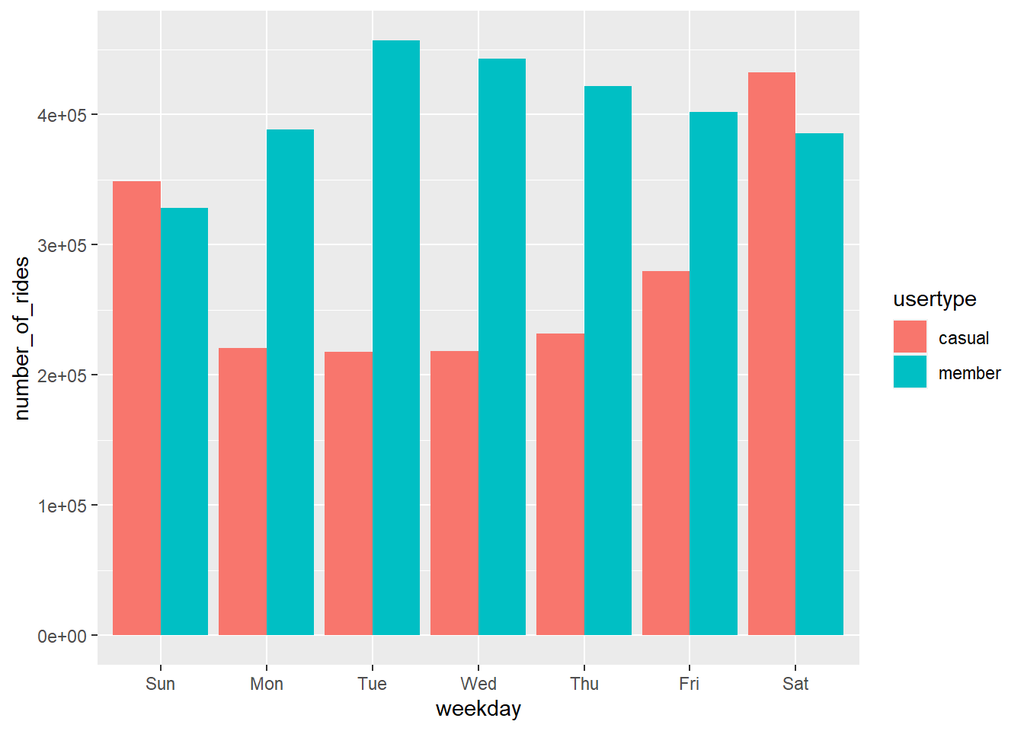

```r
# Let's visualize the number of rides by rider type
bike_share_v2 %>%
  mutate(weekday = wday(start_time, label = TRUE)) %>%
  group_by(usertype, weekday) %>%
  summarise(number_of_rides = n()
            ,average_duration = mean(ride_length)) %>%
  arrange(usertype, weekday)  %>%
  ggplot(aes(x = weekday, y = number_of_rides, fill = usertype)) +
  geom_col(position = "dodge")
```

#### Observations

Members have an almost consistent riding pattern throughout the week that rises mid week. Casual members tend to increase during weekends

### Visualize the average duration by rider type

[figure not shown]

```r
# Let's create a visualization for average duration
bike_share_v2 %>%
  mutate(weekday = wday(start_time, label = TRUE)) %>%
  group_by(usertype, weekday) %>%
  summarise(number_of_rides = n()
            ,average_duration = mean(ride_length)) %>%
  arrange(usertype, weekday)  %>%
  ggplot(aes(x = weekday, y = average_duration, fill = usertype)) +
  geom_col(position = "dodge")+
  labs(title ="average duration of Rides by Ridertype Weekly",
       caption = "Cyclistic’s historical trip data(Case Study)",
       x="Month",
       y="Average Duration of Rides")
```

#### Observations

Casual members tend to have longer ride duration than members and this pattern is consistent any day of the week

### Visualize the number of rides by rider type monthly

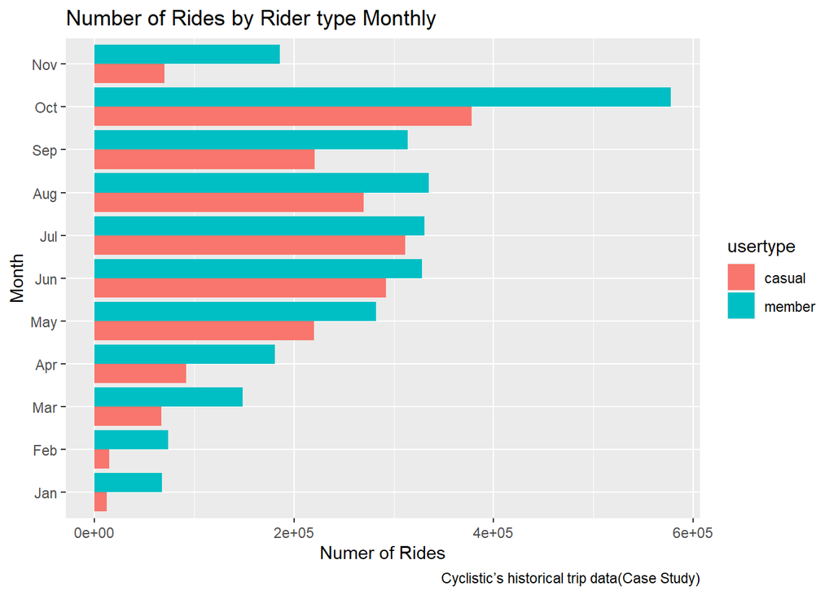

```r
# Let's visualize the number of rides by rider type monthly
bike_share_v2 %>%
  mutate(month_name = month(start_time, label = TRUE)) %>%
  group_by(usertype,year,month_name) %>%
  summarise(number_of_rides = n()
            ,average_duration = mean(ride_length)) %>%
  arrange(usertype,year, month_name)  %>%
  ggplot(aes(x = number_of_rides, y = month_name, fill = usertype , group = factor(usertype ))) +
  geom_col(position = "dodge")+
  labs(title ="Number of Rides by Rider type Monthly",
       caption = "Cyclistic’s historical trip data(Case Study)",
       x="Numer of Rides",
       y="Month")
```

### A snap Analysis of bike type used by rider type Monthly

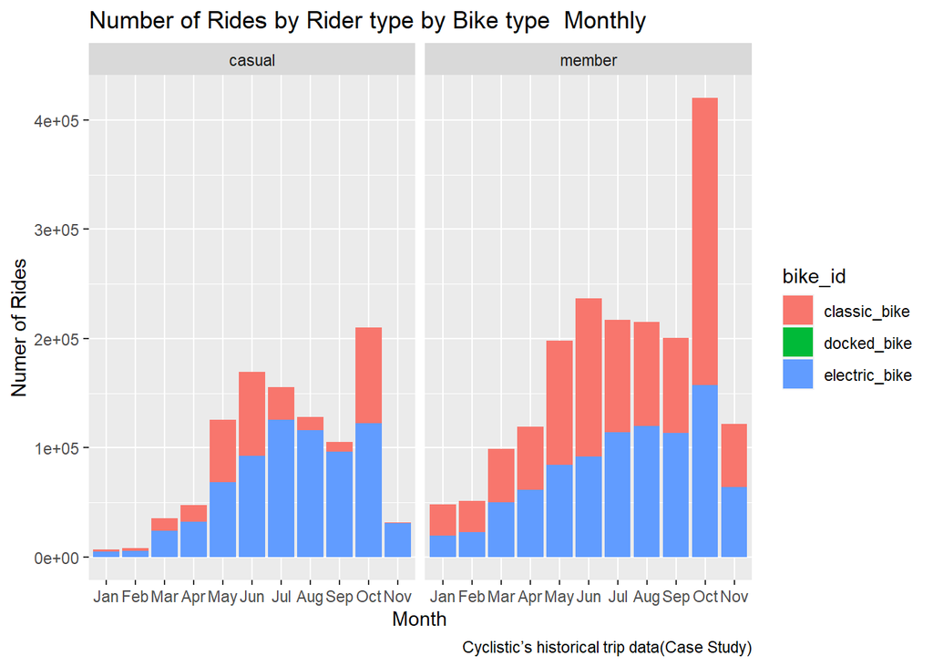

```r
#A snap Analys of bike type used by rider type Monthly
bike_share_v2 %>%
  mutate(month_name = month(start_time, label = TRUE)) %>%
  group_by(usertype,bike_id,month_name) %>%
  summarise(number_of_rides = n()
            ,average_duration = mean(ride_length)) %>%
  arrange(usertype, month_name)  %>%
  ggplot(aes(x =month_name , y = number_of_rides, fill = bike_id , group = factor(usertype ))) +
  geom_col(position = "dodge")+
  facet_wrap(~usertype)+
  labs(title ="Number of Rides by Rider type by Bike type  Monthly",
       caption = "Cyclistic’s historical trip data(Case Study)",
       x="Month",
       y="Numer of Rides")
```

#### Observations

Classic and electric bikes are the most used bikes.

### A snap Analysis of bike type used by rider type weekly

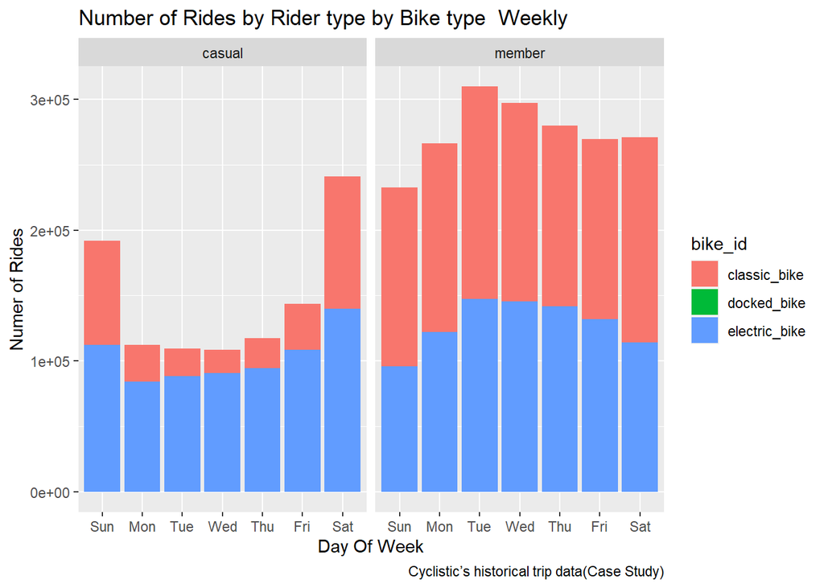

```r
#A snap Analysis of bike type used by rider type weekly
bike_share_v2 %>%
  mutate(weekday = wday(start_time, label = TRUE)) %>%
  group_by(usertype,bike_id,weekday) %>%
  summarise(number_of_rides = n()
            ,average_duration = mean(ride_length)) %>%
  arrange(usertype, weekday)  %>%
  ggplot(aes(x =weekday , y = number_of_rides, fill = bike_id , group = factor(usertype ))) +
  geom_col(position = "dodge")+
  facet_wrap(~usertype)+
  labs(title ="Number of Rides by Rider type by Bike type  Weekly",
       caption = "Cyclistic’s historical trip data(Case Study)",
       x="Day Of Week",
       y="Numer of Rides")
```

### A snap Analysis of bike type used by rider type

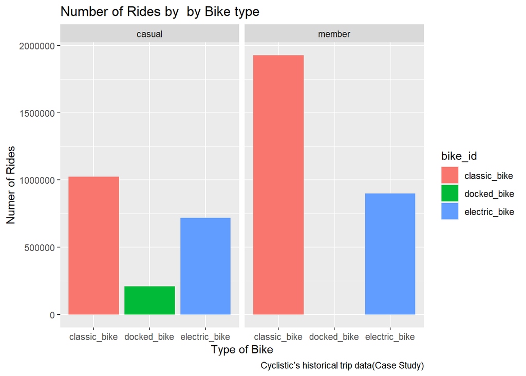

```r
#A snap Analysis of bike type used by rider type
bike_share_v2 %>%
  mutate(weekday = wday(start_time, label = TRUE)) %>%
  group_by(usertype,bike_id) %>%
  summarise(number_of_rides = n()
            ,average_duration = mean(ride_length)) %>%
  arrange(usertype,bike_id)  %>%
  ggplot(aes(x =bike_id , y = number_of_rides, fill = bike_id , group = factor(usertype ))) +
  geom_col(position = "dodge")+
  facet_wrap(~usertype)+
  labs(title ="Number of Rides by  by Bike type  ",
       caption = "Cyclistic’s historical trip data(Case Study)",
       x="Type of Bike",
       y="Numer of Rides")
```

### Total Casual members ride vs member rides

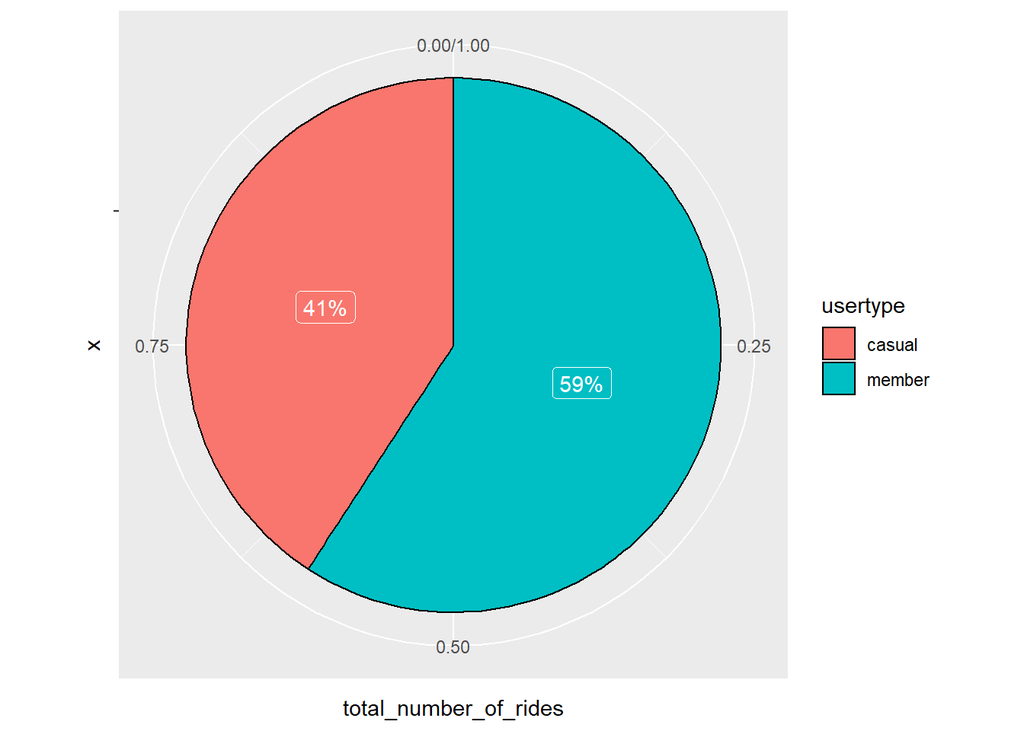

```r
#Total Casual members ride vs member rides
bike_share_v2 %>%
  group_by(usertype) %>%
  summarise(number_of_rides = n()
            ,average_duration = mean(ride_length)) %>%
  mutate(total_number_of_rides = `number_of_rides` / sum(`number_of_rides`)) %>%
  mutate(labels = scales::percent(total_number_of_rides,accuracy = 1L)) %>%
  ggplot( aes(x = "", y = total_number_of_rides, fill = usertype)) +
  geom_col(color = "black") +
  geom_label(aes(label =  labels),
             color = "white",
             position = position_stack(vjust = 0.5),
             show.legend = FALSE) +
  coord_polar(theta = "y")
```

#### Observations

Generally the number of rides is bigger for members, with casual members forming 41% of the riders

# Act: Key Findings & Recommendations

### Limitations

The following Limitations and or assumptions where made: + All records without start and destination station where omitted. + Information about the gender of participants unknown and was not considered. + Pricing structure was not stated. this could influence a rider choosing a package.